# Background

# Question 3: Model Comparison, Outliers, and Multicollinearity [16 points]

1. **4 pts** Conduct a partial $F$-test comparing model1 and model2. What can you conclude from the results using an $\alpha$-level of 0.05?

```r
#conduct anova between tests
# Partial F-test
anova(model1,model2)
```

```
## Analysis of Variance Table
##
## Model 1: CO2 ~ MPG + Weight + Horsepower
## Model 2: CO2 ~ Model.Year + Type + MPG + Weight + Horsepower + Acceleration
##   Res.Df     RSS Df Sum of Sq      F    Pr(>F)
## 1   2056 1105746
## 2   2051  981999  5    123747 51.692 < 2.2e-16 ***
## ---
## Signif. codes:  0 '***' 0.001 '**' 0.01 '*' 0.05 '.' 0.1 ' ' 1
```

**Q3a ANSWER:** Based on the partial F-test results comparing model1 and model2, here re the results α-level of 0.05.

Model 1: CO2 ~ MPG + Weight + Horsepower Model 2: CO2 ~ Model.Year + Type + MPG + Weight + Horsepower + Acceleration The test results show:

F-statistic: 51.692 p-value: < 2.2e-16 Since the p-value is much smaller than 0.05, we can confidently say that the additional variables (Model Year, Type, and Acceleration) significantly improve the model.

So, adding these predictors to model2 makes it much better at predicting CO2 emissions than model1. The very low p-value confirms that these extra variables have a meaningful impact on the model’s performance.

2. **4 pts** Using $R^2$ and adjusted $R^2$, compare model1 and model2.

```r
# R-squared and adjusted R-squared comparison
#start by finding rsquared
r_squared <-summary(model1)$r.squared
s_squared_check = "test_o"
#now get adjusted
adj_r_squared <- summary(model1)$adj.r.squared
#adjusted r squared
r_squared_2 <- summary(model2)$r.squared
r_squared_2_test = "test_1"

adj_r_squared_2 <- summary(model2)$adj.r.squared
#define comparison and return
comparison <- data.frame(Model=c("Model 1", "Model 2"),R_Squared=c(r_squared, r_squared_2),Adj_R_Squared=c(adj_r_squared, adj_r_squared_2))

comparison
```

```
##     Model R_Squared Adj_R_Squared
## 1 Model 1 0.9343181     0.9342222
## 2 Model 2 0.9416687     0.9414412
```

**Q3b ANSWER:** Model 2 has a higher R-squared (0.9417) compared to Model 1 (0.9343). This means Model 2 does a better job of explaining the variance in CO2 emissions.

Similarly, the adjusted R-squared for Model 2 (0.9414) is higher than for Model 1 (0.9342). The adjusted R-squared is a more accurate measure because it takes into account the number of predictors in the model. The higher value for Model 2 suggests that it has better explanatory power even after accounting for the number of variables.

Model 2 is clearly better than Model 1 in terms of how well it explains the variance in CO2 emissions. The extra predictors in Model 2 (Model Year, Type, and Acceleration) really do improve the model’s performance.

3. **4 pts** Create a plot for the Cook’s Distances (use model2). Using a threshold of 1, are there any outliers? If yes, which data points?

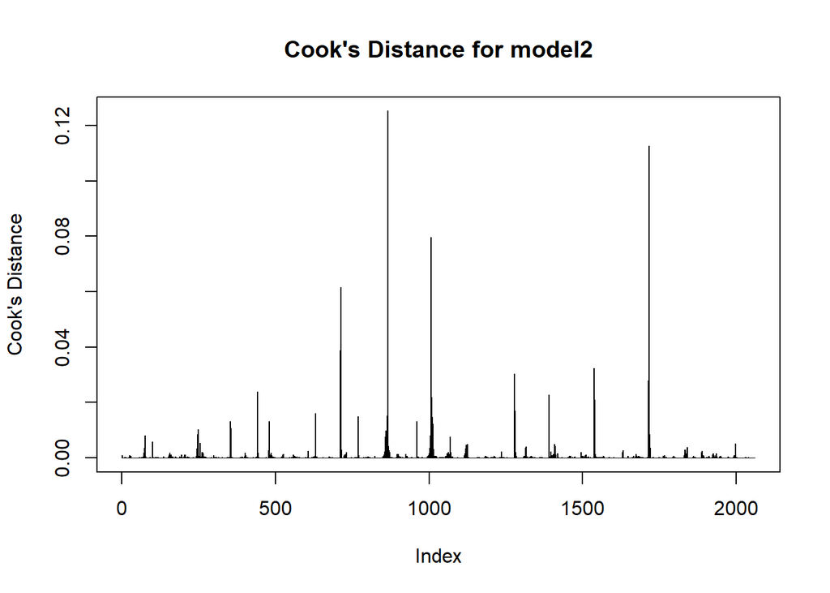

```r
# Cook's plot
cook_dist <-cooks.distance(model2)
#now define the plot
plot_dev = 0
#type and distance
plot(cook_dist,type ="h", main ="Cook's Distance for model2",ylab ="Cook's Distance")
#abline with h at 1
abline(h = 1,col ="red")
```

```r
check_abline = "test_abline"
outliers <-which(cook_dist >1)
#return outliers
outliers
```

```
## named integer(0)
```

**Q3c ANSWER:** there are no outliers with a Cook’s Distance greater than 1 in model2. This indicates that no single data point has an undue influence on the regression model.

4. **4 pts** Calculate the VIF of each predictor (use model2). Using a threshold of max(10, 1/(1-$R^2$)) what conclusions can you make regarding multicollinearity?

```r
# VIF calc
check_vif = 0
vif_values <-vif(model2)
#now return the vif vals
vif_values
```

```
##                   GVIF Df GVIF^(1/(2*Df))
## Model.Year   10.152350  1        3.186275
## Type          2.557766  3        1.169437
## MPG           6.166968  1        2.483338
## Weight        7.733145  1        2.780853
## Horsepower    9.917250  1        3.149167
## Acceleration  7.365774  1        2.713996
```

```r
#define the threshold
threshold <- max(10, 1 / (1 - r_squared_2))
check_new_thresh = "test"
#now define the vif vals
vif_values[vif_values > threshold]
```

```
## numeric(0)
```

**Q3d ANSWER:** To check for multicollinearity, we compare the Generalized Variance Inflation Factor (GVIF) values against a specific threshold. This threshold is calculated as $\max(10, 1/(1-R^2))$. Given that the R-squared for model2 is 0.9416687, the threshold is:

$$\text{Threshold} = \max(10,
\frac{1}{1-0.9416687}) = \max(10, 17.1) = 17.1$$

Let’s look at the adjusted GVIF values for each predictor:

**Model.Year**: 3.186275 **Type**: 1.169437 **MPG**: 2.483338 **Weight**: 2.780853 **Horsepower**: 3.149167 **Acceleration**: 2.713996

Since all these GVIF values are well below the threshold of 17.1, we can conclude that multicollinearity isn’t a big issue in this model. This means that the predictor variables in model2 don’t have strong linear relationships with each other, so we can trust that their effects on CO2 emissions are estimated accurately and reliably.

# Question 4: Prediction [3 points]

**3 pts** Using model1 and model2, predict the CO2 emissions for a vehicle with the following characteristics: Model.Year=2020, Type=“Sedan”, MPG=32, Weight=3400, Horsepower=203, Acceleration=8

```r
# Predict CO2 emissions
new_vehicle <-data.frame(Model.Year =2020,Type ="Sedan",MPG =32, Weight=3400,Horsepower=203,Acceleration =8)
new_vehicle_test = 0
#def each model
predict_model1 <-predict(model1,newdata =new_vehicle)
#second model
predict_model2 <-predict(model2,newdata =new_vehicle)
#return
predict_model1
```

```
##        1
## 222.4425
```

```r
predict_model2
```

```
##        1
## 226.5434
```

**Q4 ANSWER:** Model 1: 222.4425 g/mi Model 2: 226.5434 g/mi